# Final list of candidate genes

Silva Kasela

5/20/2020

## Candidate genes studies

Candidate genes from different sources:

- Hoffmann et al. 2020, Cell, *SARS-CoV-2 Cell Entry Depends on ACE2 and TMPRSS2 and Is Blocked by a Clinically Proven Protease Inhibitor*
- Blanco-Melo et al. 2020, Cell, *Imbalanced host response to SARS-CoV-2 drives development of COVID-19*
  - (Title of the pre-print: *SARS-CoV-2 launches a unique transcriptional signature from in vitro, ex vivo, and in vivo systems*)
  - Transcriptional response to SARS-CoV-2 *in vitro*, *ex vivo*, and *in vivo* models
- Gordon et al. 2020, Nature, *A SARS-CoV-2 protein interaction map reveals targets for drug repurposing*
  - (Title of the pre-print title: *A SARS-CoV-2-Human Protein-Protein Interaction Map Reveals Drug Targets and Potential Drug-Repurposing*)
  - 332 high-confidence SARS-CoV-2-human protein-protein interactions (PPIs)
- Gassen et al. 2020, bioRxiv, *Analysis of SARS-CoV-2-controlled autophagy reveals spermidine, MK-2206, and niclosamide as putative antiviral therapeutics*
- Wang, K. et al. 2020, bioRxiv, *SARS-CoV-2 invades host cells via a novel route: CD147-spike protein*
- COVID-19 Cell Atlas, https://www.covid19cellatlas.org/

#### Select candidate genes from Blanoc-Melo et al.

Genes from Blanco-Melo et al. 2020 are divided into three groups based on experimental evidence:

- In vitro tissue culture (variety of respiratory cell lines)
  - Human adenocarcinomic alveolar basal epithelial (A549) cells
    - Also, A549 cells supplemented with a vector expressing ACE2 (A549-ACE2), low-MOI infection (MOI, 0.2), because A549 lung alveolar cells are found to be relatively non-permissive to SARS-CoV-2 replication
  - Human adenocarcinomic lung epithelial (Calu-3) cells
- Ex vivo infection of primary cells (normal human bronchial epithelial (NHBE) cells)
  - NHBE cells isolated from a 79-year-old Caucasian female
- In vivo samples derived from both COVID-19 patients (and animals)
  - Compared post-mortem lung samples from two COVID-19-positive patients with biopsied healthy lung tissue from uninfected individuals.

Note about differential expression analysis:

- DE analysis performed by matching each experimental condition with a corresponding mock treated sample that counted for the cell type, collection time, concurrent animal controls, etc.

**1) Overlap between DEGs from different experiments**

- Adjusted p-value < 0.05
  - Adj p-values = 0 in the DE results files from cell lines -> possible bug? -> changing these p-values = 1

*In vitro cell lines kept separately or taking the intersection to form one cluster*

```
##     in vitro\n(Calu-3) in vitro\n(A549-ACE2*)                ex vivo
##                   6978                   4305                    553
##                in vivo
##                   1910
```

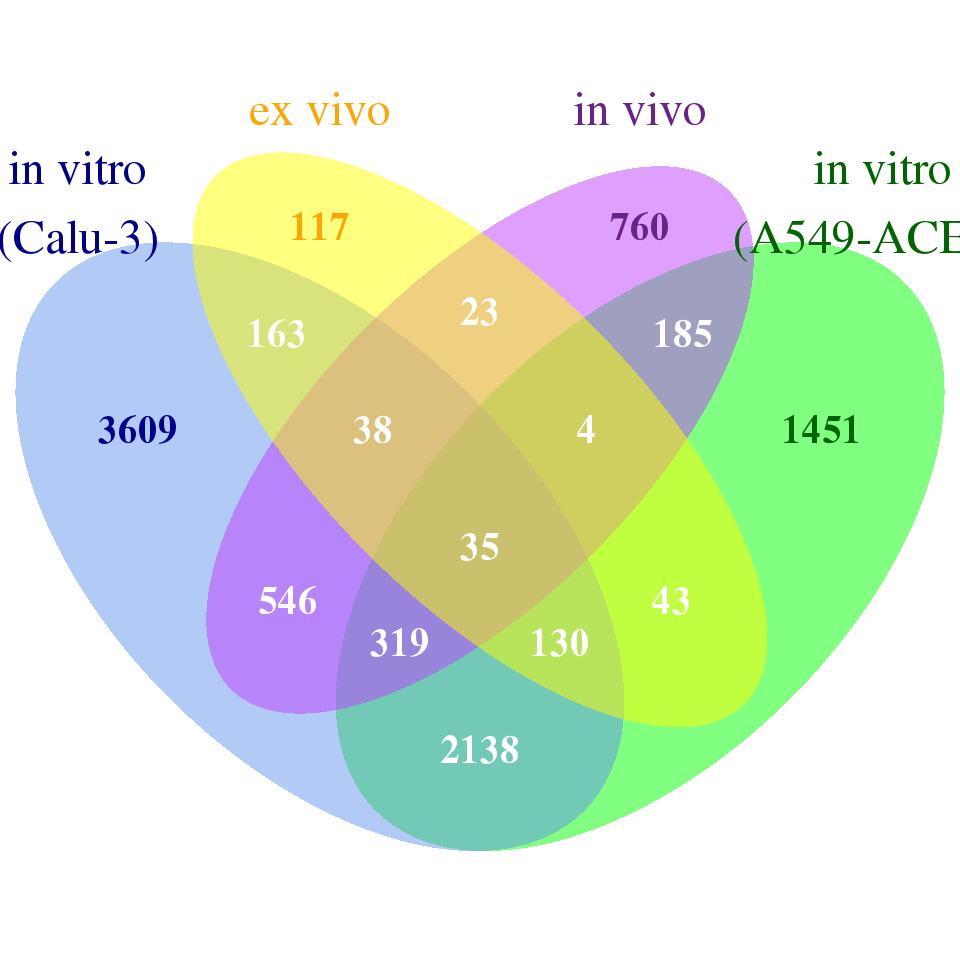

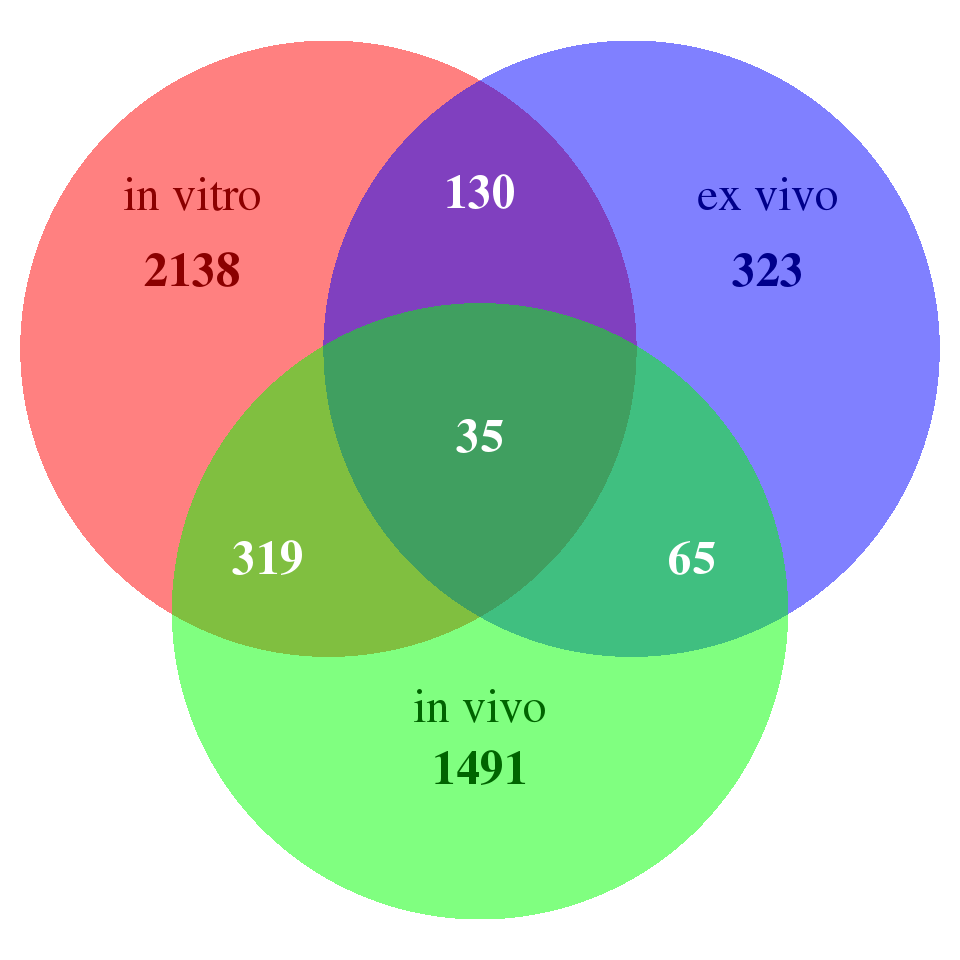

Effects sizes in these datasets:

- Calu-3

```
##    Min. 1st Qu.  Median    Mean 3rd Qu.    Max.
##  0.1682  0.4770  0.6697  0.8336  0.9818  7.8779
```

- A549-ACE2 (LowMOI)

```
##    Min. 1st Qu.  Median    Mean 3rd Qu.    Max.
##  0.1403  0.4705  0.6519  0.7804  0.9220  6.6113
```

- Primary cells (NHBE)

```
##    Min. 1st Qu.  Median    Mean 3rd Qu.    Max.
##  0.1945  0.3528  0.4684  0.6144  0.7183  2.9492
```

- Human experiment

```
##    Min. 1st Qu.  Median    Mean 3rd Qu.    Max.
##   1.334   2.594   2.922   3.045   3.376   8.935
```

**2) Overlap between DEGs from different experiments**

- Adjusted p-value < 0.05 & abs(log2 FC) > 0.5 or 1 in primary cell dataset and other datasets, respectively
  - Adj p-values = 0 in the DE results files from cell lines -> possible bug? -> changing these p-values = 1

*In vitro cell lines kept separately or taking the intersection to form one cluster*

```
##     in vitro\n(Calu-3) in vitro\n(A549-ACE2*)                ex vivo
##                   1676                    900                    248
##                in vivo
##                   1910
```

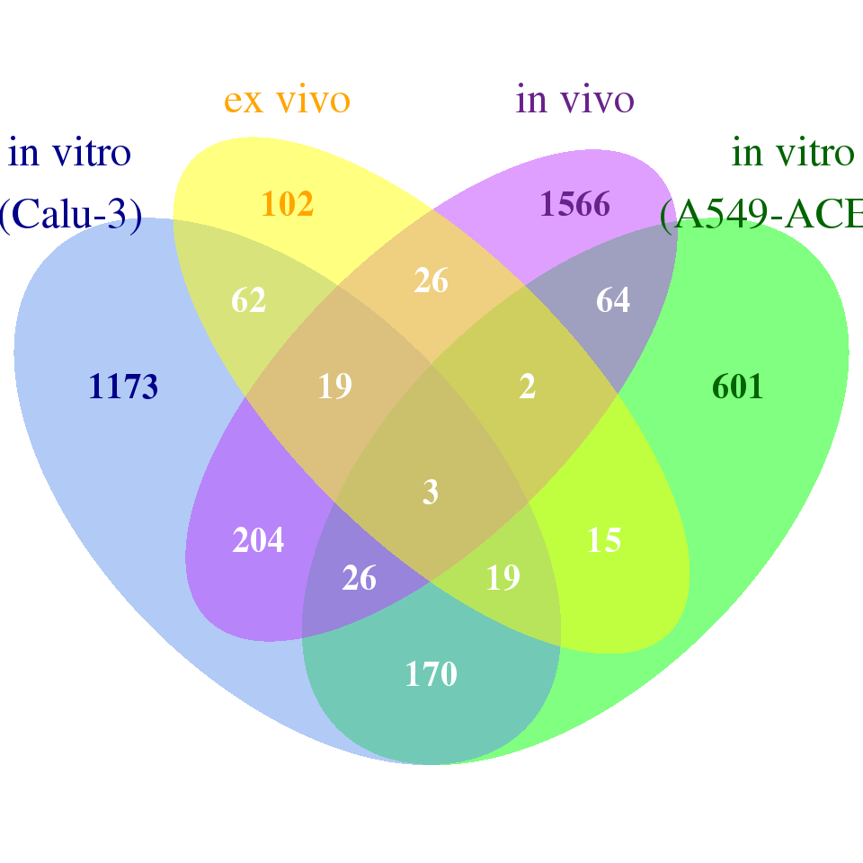

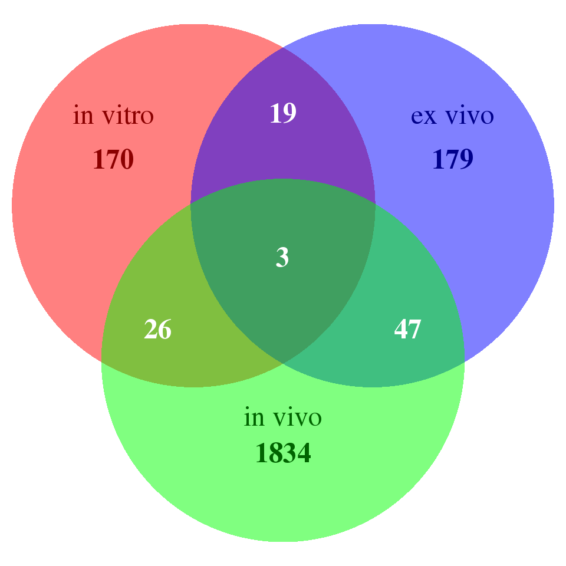

#### Selection

For final candidate genes list, select genes that have

- adjusted P-value < 0.05 in the differential expression analysis from primary cells and either cell lines (Calu-3 or ACE2-expressing A549 cells, low-MOI infection; excluded genes with adjusted P = 0) or samples derived from COVID-19 patients
- log2 fold change > 0.5 in absolute scale in primary cells and log2 fold change > 1 in absolute scale in the other experiment
- 146 genes for final candidate gene set

## Overview of the candidate gene list

- Note: gene names are matching gencode v33 (changes for genes that are listed by one of their synonym)

```
## Genes that do not have a match from gencode -  LOC100294145, MGC12916
```

#### Final list of candidate genes

- **514** candidate genes in the filtered list

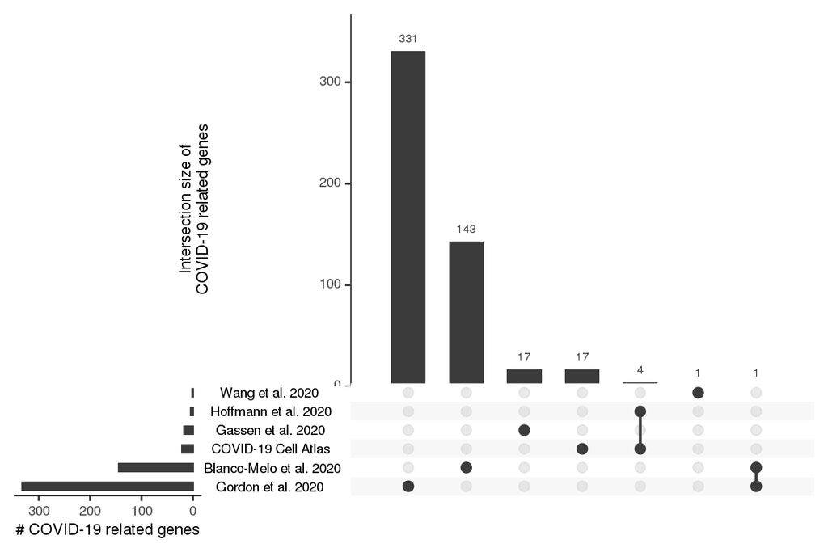

Gene biotype

```
##                                 is expressed in spiromics
## gene biotype                       0   1 Sum
##   polymorphic_pseudogene           0   1   1
##   protein_coding                  18 494 512
##   transcribed_unitary_pseudogene   0   1   1
##   Sum                             18 496 514
```

Candidate genes not expressed in SPIROMICS bronchial epithelium samples:

| gene_id | gene_name | gene_type | ref | ref_title | experimental_evidence | expressed_in_spiromics |
| --- | --- | --- | --- | --- | --- | --- |
| ENSG00000173918 | C1QTNF1 | protein_coding | Blanco-Melo et al. 2020 | Imbalanced host response to SARS-CoV-2 drives development of COVID-19 | primary_cell;calu3 | 0 |
| ENSG00000115163 | CENPA | protein_coding | Blanco-Melo et al. 2020 | Imbalanced host response to SARS-CoV-2 drives development of COVID-19 | primary_cell;calu3;a549_ace2 | 0 |
| ENSG00000164400 | CSF2 | protein_coding | Blanco-Melo et al. 2020 | Imbalanced host response to SARS-CoV-2 drives development of COVID-19 | primary_cell;calu3 | 0 |
| ENSG00000147408 | CSGALNACT1 | protein_coding | Blanco-Melo et al. 2020 | Imbalanced host response to SARS-CoV-2 drives development of COVID-19 | primary_cell;calu3 | 0 |
| ENSG00000196188 | CTSE | protein_coding | COVID-19 Cell Atlas | covid19cellatlas |  | 0 |
| ENSG00000100448 | CTSG | protein_coding | COVID-19 Cell Atlas | covid19cellatlas |  | 0 |
| ENSG00000138829 | FBN2 | protein_coding | Gordon et al. 2020 | A SARS-CoV-2 protein interaction map reveals targets for drug repurposing |  | 0 |
| ENSG00000113578 | FGF1 | protein_coding | Blanco-Melo et al. 2020 | Imbalanced host response to SARS-CoV-2 drives development of COVID-19 | primary_cell;covid19_patient | 0 |
| ENSG00000139269 | INHBE | protein_coding | Gordon et al. 2020 | A SARS-CoV-2 protein interaction map reveals targets for drug repurposing |  | 0 |
| ENSG00000259207 | ITGB3 | protein_coding | Blanco-Melo et al. 2020 | Imbalanced host response to SARS-CoV-2 drives development of COVID-19 | primary_cell;covid19_patient | 0 |
| ENSG00000152969 | JAKMIP1 | protein_coding | Gordon et al. 2020 | A SARS-CoV-2 protein interaction map reveals targets for drug repurposing |  | 0 |
| ENSG00000091129 | NRCAM | protein_coding | Blanco-Melo et al. 2020 | Imbalanced host response to SARS-CoV-2 drives development of COVID-19 | primary_cell;calu3 | 0 |
| ENSG00000140519 | RHCG | protein_coding | Blanco-Melo et al. 2020 | Imbalanced host response to SARS-CoV-2 drives development of COVID-19 | primary_cell;calu3 | 0 |
| ENSG00000183032 | SLC25A21 | protein_coding | Gordon et al. 2020 | A SARS-CoV-2 protein interaction map reveals targets for drug repurposing |  | 0 |
| ENSG00000198732 | SMOC1 | protein_coding | Gordon et al. 2020 | A SARS-CoV-2 protein interaction map reveals targets for drug repurposing |  | 0 |
| ENSG00000203785 | SPRR2E | protein_coding | Blanco-Melo et al. 2020 | Imbalanced host response to SARS-CoV-2 drives development of COVID-19 | primary_cell;covid19_patient | 0 |
| ENSG00000159167 | STC1 | protein_coding | Blanco-Melo et al. 2020 | Imbalanced host response to SARS-CoV-2 drives development of COVID-19 | primary_cell;covid19_patient | 0 |
| ENSG00000113739 | STC2 | protein_coding | Gordon et al. 2020 | A SARS-CoV-2 protein interaction map reveals targets for drug repurposing |  | 0 |

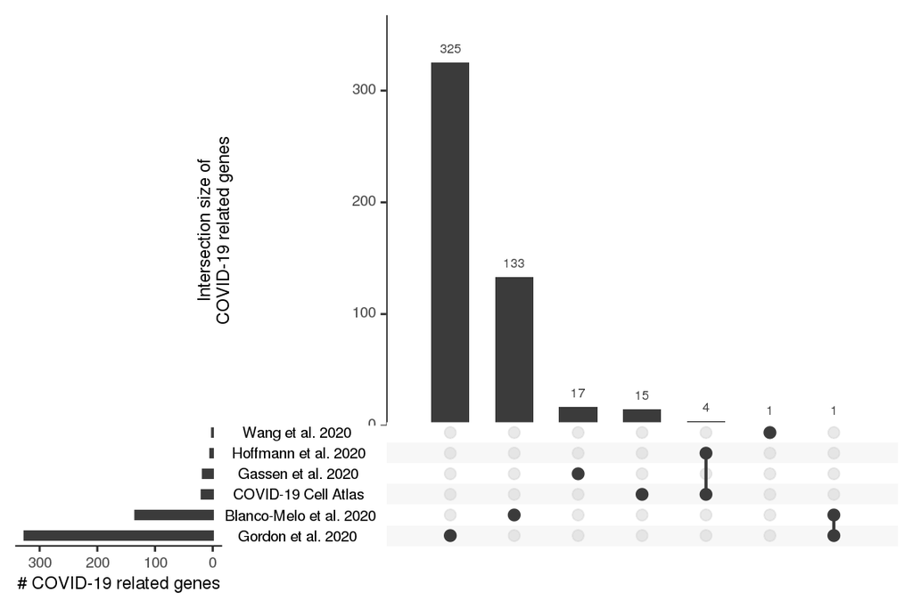